# Introduction to the debiasedmcmc package: unbiased MCMC on a univariate Normal target

Pierre E. Jacob

2019-06-10

## Introduction

This script accompanies the article “Unbiased Markov chain Monte Carlo with couplings”, by Pierre E. Jacob, John O’Leary and Yves F Atchade. The paper is available here: https://arxiv.org/abs/1708.03625.

The purpose of the package is to reproduce the figures of the article, nothing more. Some of the functions in there might be useful to other people, so a minimal effort has been made to make them understandable, via vignettes and the package documentation. However this is not a general purpose package, it has not been thoroughly tested, and you should use it at your own risk.

This script illustrates how the bias of a random walk Metropolis-Hastings (MH) algorithm. The bias, sometimes called the “burn-in bias”, stems from the chains not starting at stationarity, but instead from an arbitrary initial distribution. That bias can be removed using couplings of Markov chains, as per

- *Exact estimation for Markov chain equilibrium expectations* by Peter W. Glynn and Chang-Han Rhee, https://projecteuclid.org/euclid.jap/1417528487

Our work builds upon the above article to remove the bias of generic MCMC algorithms. One the bias is removed, various tasks are made easier, such as parallelizing MCMC computations.

We begin by loading the package, as well as extra packages for parallel calculations, registering multiple cores and setting the random number generator.

```r
library(debiasedmcmc)
library(doParallel)
library(doRNG)
# register parallel cores
registerDoParallel(cores = 2)
# set RNG seed
set.seed(1)
```

## Target distribution and MCMC algorithm

The target distribution $\pi$ is here defined as $\mathcal{N}(0,1)$. We consider an MH algorithm with Normal random walk proposals, with a proposal standard deviation of $1$. The initial distribution $\pi_0$ is chosen as $\mathcal{N}(10,1)$. The following code defines the target via its probability density function (returning log-values), and the MH kernel.

```r
# target log-pdf
logtarget <- function(x) dnorm(x, mean = 0, sd = 1, log = TRUE)
# initial distribution
rinit <- function(){
  chain_state <- rnorm(1, 10, 1)
  current_pdf <- logtarget(chain_state)
  return(list(chain_state = chain_state, current_pdf = current_pdf))
}
# MH kernel
sd_proposal <- 1
MH_kernel <- function(state){
  chain_state <- state$chain_state
  current_pdf <- state$current_pdf
  proposal <- rnorm(1, chain_state, sd_proposal)
  proposal_pdf <- logtarget(proposal)
  if (log(runif(1)) < (proposal_pdf - current_pdf)){
    return(list(chain_state = proposal, current_pdf = proposal_pdf))
  } else {
    return(list(chain_state = chain_state, current_pdf = current_pdf))
  }
}
```

The implementation of the Markov kernel takes a list (“state”) as input, and returns a list. The idea is that it must be able to take as an input whatever it returns as an output. Furthermore, “rinit” is a function that outputs a list that can be given to “MH_kernel” as an input. For illustration the above code shows that these lists can contain more than the current state of the Markov chain. Above they contain previously-computed target pdf evaluations, with the aim of speeding-up forthcoming computations.

We can check that the algorithm is correctly implemented by sampling many iterations, in the usual MCMC way, and plotting the histogram of the chain overlaid with the target probability density function.

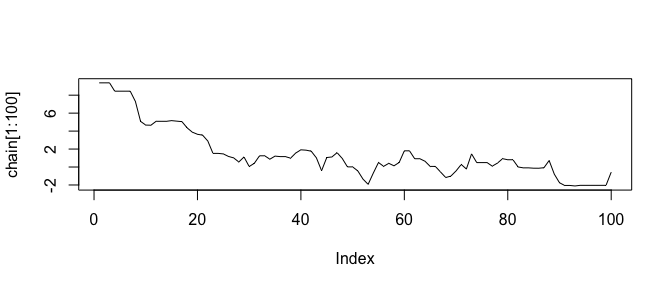

```r
niterations <- 10000
chain <- rep(0, niterations)
state <- rinit()
for (i in 1:niterations){
  state <- MH_kernel(state)
  chain[i] <- state$chain_state
}
# trace plot
plot(chain[1:100], type = "l")
```

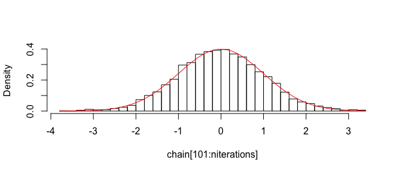

```r
# histogram of the chain after removing 100 first iterations
hist(chain[101:niterations], prob = TRUE, nclass = 40, main = "")
curve(exp(logtarget(x)), add = TRUE, col = "red")
```

## Coupled MCMC kernel

We now introduce a coupled MH kernel, obtained by maximally coupling the Normal proposals. The code to sample from a maximal coupling of two Normals is provided below.

```r
rnorm_max_coupling <- function(mu1, mu2, sigma1, sigma2){
  x <- rnorm(1, mu1, sigma1)
  if (dnorm(x, mu1, sigma1, log = TRUE) + log(runif(1)) <
        dnorm(x, mu2, sigma2, log = TRUE)){
    return(list(xy = c(x,x), identical = TRUE))
  } else {
    reject <- TRUE; y <- NA
    while (reject){
      y <- rnorm(1, mu2, sigma2)
      reject <- (dnorm(y, mu2, sigma2, log = TRUE) + log(runif(1)) <
                   dnorm(y, mu1, sigma1, log = TRUE))
    }
    return(list(xy = c(x,y), identical = FALSE))
  }
}
```

The function “rnorm_max_coupling” takes two means and two standard deviations as inputs, and returns a pair of samples $(X,Y)$ such that $X$ follows the first specified Normal, $Y$ follows the second specified Normal, and sometimes the two samples take identical values. The returned list contains a boolean variable named “identical” which is true if $X=Y$.

We next test that the above code produces the desired output.

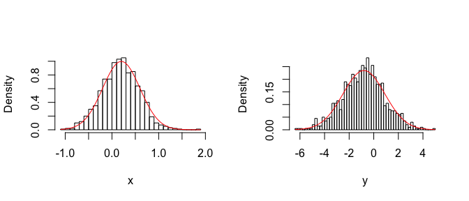

```r
mu1 <- 0.2
mu2 <- -0.8
sigma1 <- 0.4
sigma2 <- 1.7
xy <- foreach(i = 1:1000) %dorng% {
  rnorm_max_coupling(mu1, mu2, sigma1, sigma2)
}
par(mfrow = c(1,2))
hist(sapply(xy, function(x) x$xy[1]), prob = TRUE, nclass = 40, main = "", xlab = "x")
curve(dnorm(x, mu1, sigma1), add = TRUE, col = "red")
hist(sapply(xy, function(x) x$xy[2]), prob = TRUE, nclass = 40, main = "", xlab = "y")
curve(dnorm(x, mu2, sigma2), add = TRUE, col = "red")
```

```r
print(mean(sapply(xy, function(x) x$identical)))
```

```
#> [1] 0.357
```

We next define a coupled MH kernel, using maximally coupled proposals obtained with the function “rnorm_max_coupling”. It also uses the same uniform variable to accept or reject the two proposals.

```r
coupledMH_kernel <- function(state1, state2){
  chain_state1 <- state1$chain_state;  current_pdf1 <- state1$current_pdf
  chain_state2 <- state2$chain_state;  current_pdf2 <- state2$current_pdf
  # proposal from a maximal coupling
  proposal <- rnorm_max_coupling(chain_state1, chain_state2, sd_proposal, sd_proposal)
  proposal_pdf1 <- logtarget(proposal$xy[1])
  # only compute target pdf on 2nd proposal if it is not identical to 1st proposal
  proposal_pdf2 <- proposal_pdf1
  if (!proposal$identical){
    proposal_pdf2 <- logtarget(proposal$xy[2])
  }
  logu <- log(runif(1))
  accept1 <- FALSE; accept2 <- FALSE
  if (is.finite(proposal_pdf1)){
    if (logu < (proposal_pdf1 - current_pdf1)){
      accept1 <- TRUE
      chain_state1 <- proposal$xy[1]; current_pdf1 <- proposal_pdf1
    }
  }
  if (is.finite(proposal_pdf2)){
    if(logu < (proposal_pdf2 - current_pdf2)){
      accept2 <- TRUE
      chain_state2 <- proposal$xy[2]; current_pdf2 <- proposal_pdf2
    }
  }
  identical_ <- proposal$identical && accept1 && accept2
  return(list(state1 = list(chain_state = chain_state1, current_pdf = current_pdf1),
              state2 = list(chain_state = chain_state2, current_pdf = current_pdf2),
              identical = identical_))
}
```

The above function takes two states, which are lists such as the ones produced by “rinit” and “MH_kernel”. It outputs two new states, as well as a boolean indicating whether the two states are identical. In the present setting, the two new states are identical if the proposed states are identical and if they are both accepted.

In our article (https://arxiv.org/abs/1708.03625) we discuss the above coupling as well as alternatives that are better suited to higher-dimensional targets. In particular, for random walk MH we would recommend using “reflection-maximal” couplings instead of naive maximal couplings. But in the present simple scenario and for illustration purposes, it does not really matter, thus we proceed.

## Meeting times

We can now run coupled chains. More precisely, we will run chains with a time lag. That is, we construct pairs of chains as follows:

- draw $X_0$ and $Y_0$ from the initial distribution $\pi_0$, independently,
- draw $X_t|X_{t-1}\sim P(X_{t-1},\cdot)$ for $t=1,\ldots,L$, with a default lag of $L=1$,
- draw $(X_{t},Y_{t-L})$ given $(X_{t-1},Y_{t-L-1})$ using the coupled kernel $\bar{P}$, for $t>L$.

We can run the chains until they meet, i.e. until $X_t = Y_{t-L}$, and report the meeting time $\tau = \inf\{t\geq L: X_t = Y_{t-L}\}$. The following code uses the function “sample_meetingtime” to do this.

```r
sample_meetingtime(MH_kernel, coupledMH_kernel, rinit, lag = 1)
```

```
#> $meetingtime
#> [1] 2
#>
#> $elapsedtime
#> [1] 0
```

We then sample $1000$ independent copies of meeting times, and plot a histogram of them

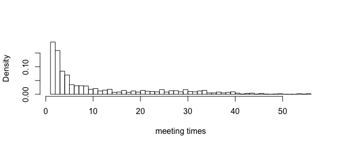

```r
nsamples <- 1000
meetings_ <-  foreach(irep = 1:nsamples) %dorng% {
  sample_meetingtime(MH_kernel, coupledMH_kernel, rinit, lag = 1)
}
meetingtime <- sapply(meetings_, function(x) x$meetingtime)
hist(meetingtime, breaks = 1:max(meetingtime), prob = TRUE, main = "", xlab = "meeting times")
```

We see that the meetings tend to occur in the first 50 iterations or so. This is very much target-specific and algorithmic-specific. Meeting times can be shorter or longer than that. In order to obtain short meeting times we need both a fast mixing MCMC kernel for the target distribution at hand, and an effective coupling strategy.

## Unbiased estimators of target expectations

Following the heuristics given in the article, we define $k$ as a large quantile of the meeting times, and $m$ as a multiple of $k$, e.g. $5k$. We then run coupled chains until time $\max(\tau, m)$, and produce unbiased estimators $H_{k:m}$ out of them. Each has expectation equal to $\int h(x) \pi(dx)$, where $h$ represents a test function of interest (this is what “unbiasedness” means). To produce these estimators, we use the function “sample_coupled_chains”, which records the trajectories of the chains. We then feed the output to the function “H_bar”, which computes for each pair of chain an unbiased estimator of a test function of interest $h$. Specifically, here we aim at approximating the mean of the target expectation (which we know is equal to zero here), so the test function is $h:x\mapsto x$. Note that we specify $m$ to the function “sample_coupled_chains”, and we specify $h$, $k$ and $m$ to the function “H_bar”.

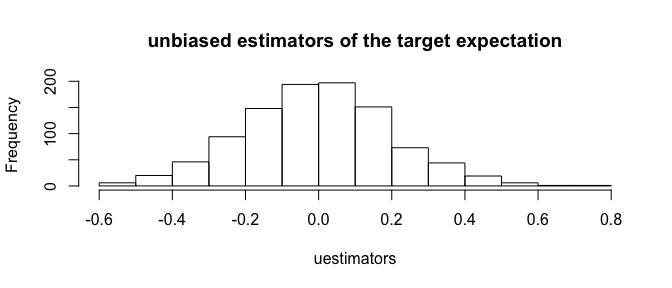

```r
k <- 50
m <- 5*k
nsamples <- 1000
coupled_chains_ <-  foreach(irep = 1:nsamples) %dorng% {
  sample_coupled_chains(MH_kernel, coupledMH_kernel, rinit, m = m)
}

uestimators <- sapply(coupled_chains_,
                      function(chains) H_bar(chains, h = function(x) x, k = k, m = m))
hist(uestimators, main = "unbiased estimators of the target expectation")
```

```r
CI_low <- mean(uestimators)  - 1.96 * sd(uestimators)/sqrt(nsamples)
CI_high <- mean(uestimators) + 1.96 * sd(uestimators)/sqrt(nsamples)
cat("Confidence interval for the target expectation: [", CI_low, ",", CI_high, "]\n")
```

```
#> Confidence interval for the target expectation: [ -0.01631993 , 0.008612045 ]
```

Above we also reported a confidence interval at level $95\%$ for the estimand $\int x \pi(dx)=0$, obtained via a central limit theorem approximation.

In the above code we could replace the test function $h$ in the call to “H_bar”, by any other function. The function is applied to the entry “chain_state” of the Markov chain. However, if are interested only in one test function $h$, we can use the function “sample_unbiasedestimator” which computes the estimators on the fly, and thus does not require as much memory as “sample_coupled_chains”. For instance, the following code estimates the second moment of $\pi$, which we know is equal to one here.

```r
uestimators_ <-  foreach(irep = 1:nsamples) %dorng% {
  sample_unbiasedestimator(MH_kernel, coupledMH_kernel,
                           rinit, h = function(x) x^2, k = k, m = m)
}
uestimators <- sapply(uestimators_, function(ue) ue$uestimator)
CI_low <- mean(uestimators)  - 1.96 * sd(uestimators)/sqrt(nsamples)
CI_high <- mean(uestimators) + 1.96 * sd(uestimators)/sqrt(nsamples)
cat("Confidence interval for the target second moment: [", CI_low, ",", CI_high, "]\n")
```

```
#> Confidence interval for the target second moment: [ 0.9885286 , 1.021437 ]
```

```r
cat("Average cost:", mean(sapply(uestimators_, function(ue) ue$cost)))
```

```
#> Average cost: 260.248
```

The above code reports a confidence interval as well as the average compute cost, measured in numbers of calls to the Markov kernel (counting twice for calls to the coupled kernel).

## Histograms

We might not be interested in specific test functions, but rather in approximation and visualization of marginal distributions. The package provides a function “histogram_c_chains” that takes a list of coupled chains, such as produced above with “sample_coupled_chains”, and computes a histogram of the desired component. The following code illustrates this functionality.

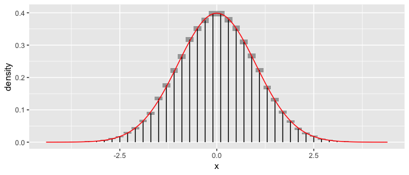

```r
histogram <- histogram_c_chains(coupled_chains_, component = 1, k = k, m = m, nclass = 50)
library(ggplot2)
g <- plot_histogram(histogram, with_bar = T)
g <- g + stat_function(fun = function(x) exp(logtarget(x)), colour = "red", alpha = 1)
g
```

The above plot shows the estimated posterior masses in vertical black bars. The grey rectangles provide $95\%$ confidence intervals on each bar separately (not jointly). The red curve adds the target pdf onto this.

The “histogram_c_chains” function takes a list of coupled chains, a component index (here equal to $1$), the values of $k$ and $m$, and a desired number of classes. Alternatively, one can specify the breaks of the histogram as a vector, with the argument ‘breaks’.